# Outlier Detection in Time Series

## UC Berkeley w271 Project, Fall 2025

# 1. Introduction

Outlier and anomaly detection plays a important role in time-series analysis, especially in applied operational settings where data drives decisions. In passenger transportation, revenue and demand series often contain spikes or drops caused by policy changes, operational disruptions, seasonal events, and data quality issues. These irregularities can distort trend estimation, bias forecasting models, and ultimately lead to misinformed operational or regulatory decisions.

In this article, I focus on anomaly detection for a key performance indicator used in the passenger transportation sector: revenue from ride-hailing services. The dataset comes from an internal indicator system that tracks month-to-month operational metrics for taxi and ride-hailing (TNS) markets (I acquired the data through my role as a government economist, but since the data is aggregated and has since been published in public facing newsletters, I am in compliance with confidentiality or privicy requirements). Revenue-based indicators are particularly prone to outliers because of data-entry issues, missing submissions, pricing irregularities, or other market shocks that can create large deviations from the underlying trend.

My goals in this post are:

1. Introduce several widely used anomaly-detection frameworks in time-series analysis
   - Statistical residual-based methods
   - Robust decomposition methods
   - Automated anomaly detection algorithms
2. Apply these methods to the trip revenue series to identify, visualize, and compare anomalies.
3. Moreover, I interpret anomaly patterns in a way that can provide operational insights. For example:
   - Are anomalies tied to seasonal spikes?
   - Are they one-off **structural** level shifts?
   - Are they caused by reporting gaps or known industry events?
4. Compare methods and highlight their strengths and limitations when used on real-world regulatory or operational data.

# 2. Mathematical and Intuitive Foundations of the Methods

This section introduces the three classes of anomaly-detection methods used later.  
Each method is based on a different statistical principle:

1. **Residual-based statistical detection**
2. **Robust trend–seasonal decomposition methods**
3. **Automated anomaly detection algorithms**

Although each method identifies “unusual” behavior, they differ fundamentally in *what* they consider an anomaly and *how* they separate “signal” from “noise”.

## 2.1 Residual-Based Statistical Methods

### **The idea**

$$ \lvert e_t \rvert = \lvert y_t - \hat{y}_t \rvert \text{ is unusually large.} $$

Here:

- $\hat{y}_t$ = model’s prediction
- $e_t = y_t - \hat{y}_t$ = residual

### **Z-score approach (as suggested in a HW with exchange rate data)**

A residual is anomalous if:

$$ \lvert e_t \rvert > k \cdot \sigma_e, $$

where:

- $\sigma_e$ is the residual standard deviation
- $k$ is typically between 2.5 and 3.5

The residuals capture variation that the model *does not* explain. And note that in this case **model** can be any underlying data-generating processes such as time trend (linear, polynomial), random walk, or white noise. If we observe large residuals, it means that there might exist unexpected behavior which can be identified as anomalies. In terms of pros and cons:

#### **Pros**

- Simple and interpretable
- Fast to compute
- Works well when model fits the data

#### **Cons**

- Sensitive to model misspecification
- If the data is innately noisy, $\sigma_e$ is inflated and detection power of this method will be reduced
- Does not distinguish structural shifts from spikes

Residual-based methods work best when the data is stable and well-modeled.

## 2.2 Robust Trend–Seasonal Decomposition (STL / LOESS)

### **The idea**

Decompose the time series:

$$ y_t = T_t + S_t + R_t, $$

where:

- STL stands for Seasonal-Trend decomposition using LOESS
- LOESS stands for locally estimated scatterplot smoothing
- $T_t$ = trend (linear or nonlinear)
- $S_t$ = seasonal component
- $R_t$ = remainder (noise + anomalies)

In this method, STL uses **robust LOESS** and produces **3 smooth curves**

- The long-term trend
- The repeated seasonal pattern
- The leftover residuals ($R_T$, or noise + anomalies)

so extreme values do not distort $T_t$ or $S_t$.

### **Mathematical anomaly rule**

Once STL extracts the remainder:

$$ \text{Anomaly if } \lvert R_t \rvert > \tau \cdot \text{MAD}(R), $$

where $\tau > 0 $ is an important decision hyperparameter: a greater $\tau$ detects fewer outliers (more stringent decision rule). Hence, the $\tau$ is analogous to the $k$ used in the Z-score method. And, MAD = median absolute deviation (robust scale estimator):

### Median Absolute Deviation (MAD)

For a remainder series (R_t), the Median Absolute Deviation is defined as:

$$ \text{MAD}(R) = \operatorname{median}\Bigl( \, \lvert R_t - \operatorname{median}(R) \rvert \, \Bigr). $$

A common scaled version (to make it comparable to a standard deviation under normality) is:

$$ \text{MAD}_{\text{scaled}}(R) = 1.4826 \times \operatorname{median}\Bigl( \, \lvert R_t - \operatorname{median}(R) \rvert \, \Bigr). $$

In other words, STL repeatedly estimates:

1. *What is the normal seasonal pattern?*
2. *What is the normal smooth trend?*

Anything that does not fit either pattern ends up in the remainder $R_t$.

#### **Pros**

- Robust to outliers
- Handles evolving seasonality and nonlinear trends
- Easy to interpret visually

#### **Cons**

- Assumes seasonal structure exists
- Does not classify anomaly types
- Requires tuning of decomposition windows

STL works well for, say, revenue series with seasonality (e.g., monthly ridership or revenue).

## 2.3 Automated Anomaly Detection Algorithms

This family includes:

- **Isolation Forest**
- **One-Class SVM**
- **Local Outlier Factor (LOF)**
- **Twitter-style IQR + seasonal methods**
- **Prophet changepoint detection**

They differ in methodology, but share two principles:  
anomalies are *isolated quickly* or lie in *low-density regions*.

### **Idea 1: Isolation Forest — anomalies isolate easily**

Isolation Forest partitions the data recursively.  
Anomalous points need *fewer splits* to isolate.

Score:

$$ \text{AnomalyScore}(x) = 1 - \frac{E[h(x)]}{c(n)}, $$

where:

- x is an observation at a given time point (or a vector of observation at time $t$)
- n the number of observations
- $h(x)$ = path length to isolate the point
- $c(n)$ = normalization constant (e.g., expected path length given $n$ sample points split randomly)

In essence, it is a classification tree for a set of observations, and a shorter path for a given data point means it is more likely to be anomalous.

### **Idea 2: One-Class SVM — learns a boundary of normality**

One-Class SVM classifies:

$$ f(x) = \begin{cases} +1, & \text{normal} \\ -1, & \text{anomaly} \end{cases} $$

It learns a boundary that encloses the majority of data, allowing a fraction $\nu$ of anomalies outside.

### **Idea 3: Changepoint / structural detection (e.g., Prophet)**

Let $g(t)$ denote the trend component of a time-series model. Trend changes are detected when:

$$ \frac{d}{dt} g(t) $$

changes abruptly. This flags structural shifts or level changes rather than isolated spikes.

The pros and cons of algorithm based method:

### **Pros**

- Few assumptions about data distribution
- Can detect complex nonlinear anomalies
- Scales well to multidimensional data (e.g., revenue + trips + distance)

### **Cons**

- Less interpretable
- Hyperparameters matter
- Can over-flag sometimes

These methods are best for irregular anomaly patterns or datasets with complex dynamics.

## 2.4 **Summary Table**

| Method Class | Underlying Model | What Counts as an Anomaly? | Works well For |
| --- | --- | --- | --- |
| **Residual-based** | ARIMA / regression | Large residuals | Stable data, interpretable spikes |
| **STL (robust decomposition)** | Trend + season + remainder | Large robust remainder | Seasonal operational series |
| **Automated algorithms** | Density, isolation, boundaries | Deviations from learned structure | Complex or nonlinear anomalies |

# 3. Case study: Data

In this section, I load the monthly indicator dataset (`ts_data.xlsx`) that contains ride-hailing operational metrics of a North American metropolitan area of population around 3 million. I will inspect the structure, check column names, and ensure the date column is parsed correctly before proceeding to exploratory analysis.

```python
# When working in a jupyter notebook, I find it helpful to always check directory and relative path before loading data
# We can uncomment the lines below to run those BASH commands if necessasry

# !pwd
# !ls data
```

[output not shown]

[output not shown]

```python
# Loading packages (Pip install if missing from enviroment)
# I use Github Codespace VScode hence need to install some packages
import numpy as np
import pandas as pd

import matplotlib.pyplot as plt
import seaborn as sns
from statsmodels.graphics.tsaplots import plot_acf
import matplotlib.pyplot as plt
import seaborn as sns
from statsmodels.graphics.tsaplots import plot_acf

from sklearn.linear_model import LinearRegression

from statsmodels.tsa.seasonal import STL
from statsmodels.nonparametric.smoothers_lowess import lowess
```

```python
# Path to your data file
path = "data/ts_data.xlsx"

# Load the Excel file
df = pd.read_excel(path)

# Preview the first few rows
df.head()
```

|  | LEVEL_NAME | LEVEL_VALUE | PICKUP_AREA | TRIP_SERVICE_TYPE_CODE | YEAR_POINT | MONTH_POINT | INDICATOR_TYPE | INDICATOR_VALUE |
| --- | --- | --- | --- | --- | --- | --- | --- | --- |
| 0 | TNS_ZONE | NaN | NaN | TNS | 2024.0 | 1.0 | TRIP_VOLUME | 34993.0 |
| 1 | TNS_ZONE | NaN | NaN | TAXI | 2023.0 | 8.0 | TRIP_VOLUME | 8375.0 |
| 2 | TNS_ZONE | ZONE 1 | ZONE 1 | TAXI | 2025.0 | 4.0 | TRIP_VOLUME | 548105.0 |
| 3 | TNS_ZONE | ZONE 3 | ZONE 3 | TNS | 2023.0 | 4.0 | TRIP_VOLUME | 2900.0 |
| 4 | TNS_ZONE | ZONE 3 | ZONE 3 | TAXI | 2023.0 | 6.0 | TRIP_VOLUME | 40380.0 |

```python
# Filter to the target time series
ts = (
    df
    .loc[
        (df["LEVEL_NAME"] == "TNS_ZONE") &
        (df["LEVEL_VALUE"] == "ZONE 1") &
        (df["TRIP_SERVICE_TYPE_CODE"] == "TNS") &
        (df["INDICATOR_TYPE"] == "TRIP_REVENUE")
    ]
    .copy()
)

# Construct a proper datetime from YEAR_POINT and MONTH_POINT
ts["DATE"] = pd.to_datetime(
    ts["YEAR_POINT"].astype(int).astype(str) + "-" +
    ts["MONTH_POINT"].astype(int).astype(str) + "-01"
)

# Sort by date
ts = ts.sort_values("DATE")

# Keep only the relevant columns for the time series
ts = ts[["DATE", "INDICATOR_VALUE"]].rename(columns={"INDICATOR_VALUE": "REVENUE"})

# Preview
ts.head(), ts.tail()

# Scale revenue to millions of dollars
ts["REVENUE_M"] = ts["REVENUE"] / 1e6

# Keep both columns for now (optional)
ts= ts[["DATE", "REVENUE_M"]].copy()

# Drop the last row (most recent month with data quality issues)
ts= ts.sort_values("DATE").iloc[:-1].copy()

# Preview the scaled series
ts.head()
```

|  | DATE | REVENUE_M |
| --- | --- | --- |
| 319 | 2023-01-01 | 31.070735 |
| 387 | 2023-02-01 | 29.833130 |
| 464 | 2023-03-01 | 33.285455 |
| 320 | 2023-04-01 | 36.930890 |
| 412 | 2023-05-01 | 37.662681 |

```
Missing values check:
 DATE         0
REVENUE_M    0
dtype: int64

Duplication check:
 0

Missing month check:
 DatetimeIndex([], dtype='datetime64[ns]', freq='MS')

Descriptive stas:
 count    34.000000
mean     45.870015
std       7.730985
min      29.833130
25%      42.845528
50%      44.192622
75%      50.922945
max      63.390907
Name: REVENUE_M, dtype: float64
```

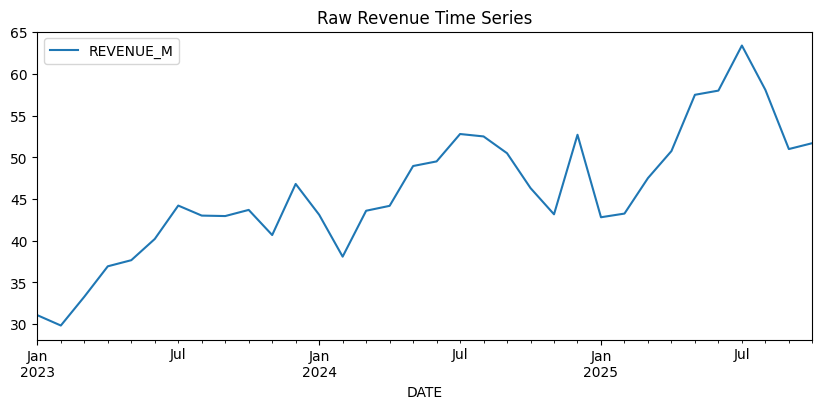

```python
# Sanity checks

# ==== 1. Check for missing values ====
print("Missing values check:\n", ts.isna().sum())

# ==== 2. Check for duplicate dates ====
print("\nDuplication check: \n", ts["DATE"].duplicated().sum())

# ==== 3. Check for gaps in monthly continuity ====
# Generate a complete monthly date range
full_range = pd.date_range(start=ts["DATE"].min(), end=ts["DATE"].max(), freq="MS")

missing_months = full_range.difference(ts["DATE"])
print("\nMissing month check: \n", missing_months)

# ==== 4. Quick descriptive statistics ====
print("\nDescriptive stas:\n", ts["REVENUE_M"].describe())

# ==== 5. Check for negative revenue ====
(ts["REVENUE_M"] < 0).sum()

# ==== 6. Basic visualization to spot extreme values ====
ts.plot(x="DATE", y="REVENUE_M", figsize=(10, 4), title="Raw Revenue Time Series");
```

# 4. Case Study: Exploratory Data Analysis (EDA)

Before applying anomaly detection methods, I explore key characteristics of the revenue series, including its overall trend, seasonal patterns, distributional properties, and basic autocorrelation structure. This helps confirm that STL decomposition and residual-based approaches are suitable for this dataset, and provides intuition for interpreting potential anomalies later.

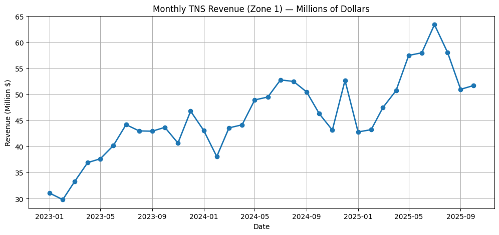

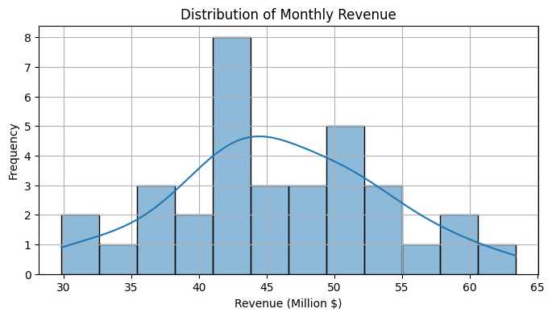

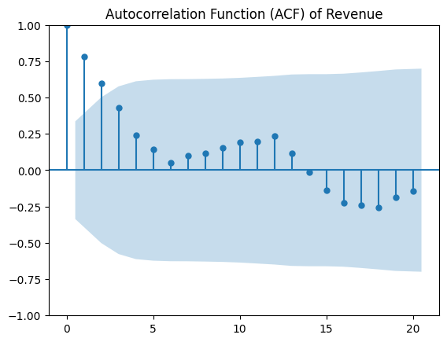

```python
# Plot the raw cleaned time series
plt.figure(figsize=(12, 5))
plt.plot(ts["DATE"], ts["REVENUE_M"], marker='o', linewidth=2)
plt.title("Monthly TNS Revenue (Zone 1) — Millions of Dollars")
plt.xlabel("Date")
plt.ylabel("Revenue (Million $)")
plt.grid(True)
plt.show()

# Histogram of revenue distribution
plt.figure(figsize=(8, 4))
sns.histplot(ts["REVENUE_M"], bins=12, kde=True)
plt.title("Distribution of Monthly Revenue")
plt.xlabel("Revenue (Million $)")
plt.ylabel("Frequency")
plt.grid(True)
plt.show()

# ACF plot to inspect autocorrelation structure
plt.figure(figsize=(10, 4))
plot_acf(ts["REVENUE_M"], lags=20)
plt.title("Autocorrelation Function (ACF) of Revenue")
plt.show()
```

# 5. Case Study: Applying Z-Score method

## 5.1 Apply Method 1: Residual-Based Anomaly Detection (Z-score Method)

The first approach follows the classical residual-based anomaly detection method. I begin by fitting a simple baseline model to the revenue series. The predicted values from this model are denoted by ( \hat{y}_t ), and anomalies are defined as unusually large residuals:

$$ e_t = y_t - \hat{y}_t, $$

and the anomaly rule is:

$$ \lvert e_t \rvert > k \cdot \sigma_e, $$

where ( \sigma_e ) is the residual standard deviation and ( k ) controls detection sensitivity (typically between 2.5 and 3.5). To keep the method transparent and interpretable, I use a linear trend model as the baseline:

$$ y_t = \beta_0 + \beta_1 t + e_t. $$

```python
# Use ts (already cleaned and scaled)
df_z = ts.copy().sort_values("DATE")

# Construct time index t = 0,1,2,...
df_z["t"] = np.arange(len(df_z))

# Fit linear regression: REVENUE_M ~ t
model = LinearRegression()
model.fit(df_z[["t"]], df_z["REVENUE_M"])

# Predictions
df_z["y_hat"] = model.predict(df_z[["t"]])

# Residuals
df_z["residual"] = df_z["REVENUE_M"] - df_z["y_hat"]

df_z.head()
```

|  | DATE | REVENUE_M | t | y_hat | residual |
| --- | --- | --- | --- | --- | --- |
| 319 | 2023-01-01 | 31.070735 | 0 | 35.301873 | -4.231138 |
| 387 | 2023-02-01 | 29.833130 | 1 | 35.942367 | -6.109236 |
| 464 | 2023-03-01 | 33.285455 | 2 | 36.582860 | -3.297405 |
| 320 | 2023-04-01 | 36.930890 | 3 | 37.223353 | -0.292463 |
| 412 | 2023-05-01 | 37.662681 | 4 | 37.863847 | -0.201166 |

```python
# Residual standard deviation
sigma_e = df_z["residual"].std()

# Choose k (e.g., 3.0)
k = 2.0

# Flag anomalies
df_z["Z_anomaly"] = df_z["residual"].abs() > k * sigma_e

print("Outliers (empty table means no outliers detected):")
df_z[df_z["Z_anomaly"] == True]
```

```
Outliers (empty table means no outliers detected):
```

|  | DATE | REVENUE_M | t | y_hat | residual | Z_anomaly |
| --- | --- | --- | --- | --- | --- | --- |
| 781 | 2025-07-01 | 63.390907 | 30 | 54.516676 | 8.874231 | True |

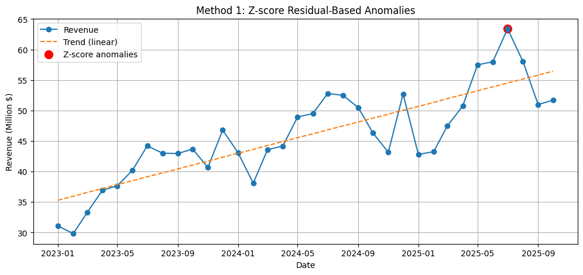

```python
plt.figure(figsize=(12,5))
plt.plot(df_z["DATE"], df_z["REVENUE_M"], label="Revenue", marker="o")
plt.plot(df_z["DATE"], df_z["y_hat"], label="Trend (linear)", linestyle="--")

# Overlay anomalies
anoms = df_z[df_z["Z_anomaly"] == True]
plt.scatter(anoms["DATE"], anoms["REVENUE_M"],
            color="red", s=100, label="Z-score anomalies")

plt.title("Method 1: Z-score Residual-Based Anomalies")
plt.xlabel("Date")
plt.ylabel("Revenue (Million $)")
plt.legend()
plt.grid(True)
plt.show()
```

## 5.1 Findings from Method 1 (Residuals based)

Using the residual-based Z-score method with a linear trend model as the baseline, only one revenue point is classified as anomalous when the sensitivity threshold is set to (k = 2). This observation occurs in July 2025 and lies nearly $9 million above the level predicted by the fitted trend. When the threshold is tightened to a more conservative (k = 3), no observations qualify as anomalies, indicating that the July 2025 value is unusual relative to short-term deviations but not extreme relative to the overall variability of the series. This result highlights both the interpretability and the sensitivity of the Z-score approach: it readily identifies points that diverge from the modeled trend, but its conclusions depend strongly on the choice of (k), especially when the underlying series contains structural growth or evolving seasonal patterns.

# 6. Case Study: Applying STL + MAD-Based Anomaly Detection

The second approach uses the STL (Seasonal-Trend decomposition using LOESS) framework. The revenue series is decomposed into trend, seasonal, and remainder components:

$$ y_t = T_t + S_t + R_t, $$

where (T_t) captures the smooth long-run trend, (S_t) captures recurring seasonal patterns, and (R_t) is the remainder (noise + potential anomalies). Because STL uses robust LOESS, extreme values have limited influence on (T_t) and (S_t), so unusual observations tend to appear as large deviations in (R_t).

Once the remainder is extracted, I use a robust MAD-based rule to flag anomalies:

$$ \text{Anomaly if } \lvert R_t \rvert > \tau \cdot \text{MAD}(R), $$

where (\tau > 0) plays a similar role to the (k) parameter in the Z-score method (larger (\tau) means fewer points are flagged).

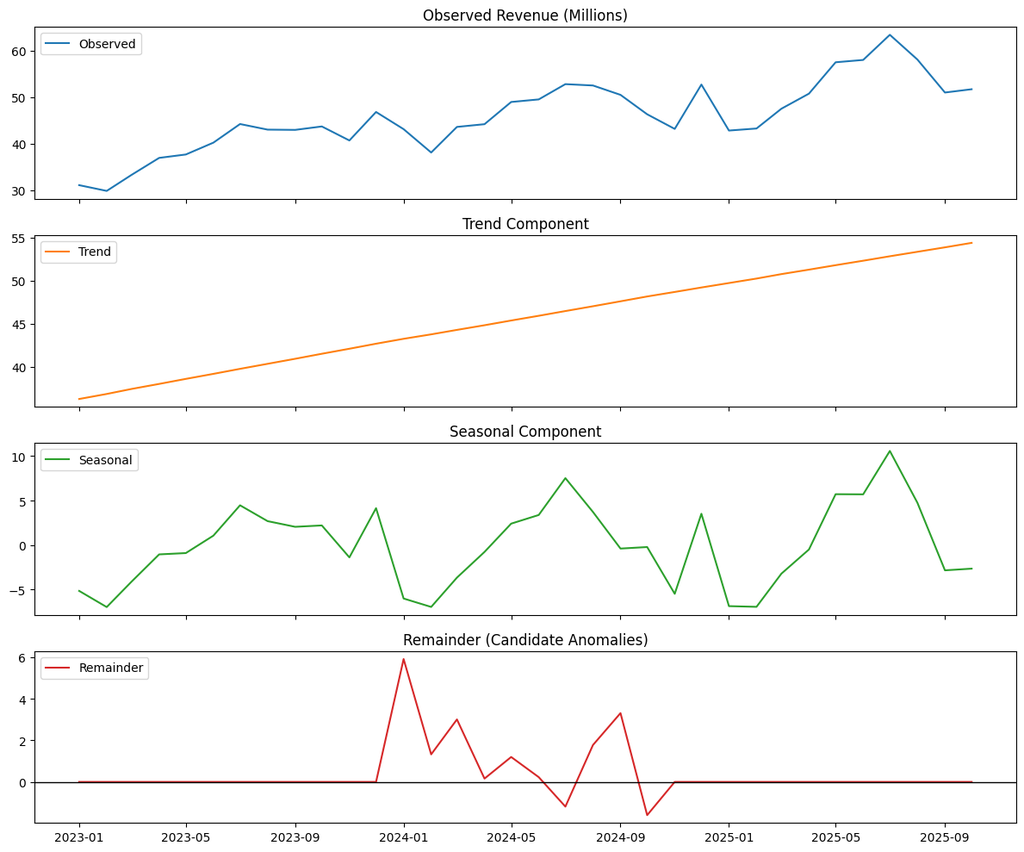

```python
# Implementing method 2

# Ensure sorted and indexed by DATE
ts_stl = ts.sort_values("DATE").set_index("DATE").copy()

y = ts_stl["REVENUE_M"]

# Run STL decomposition with yearly seasonality (period=12 for monthly data)
stl = STL(y, period=12, robust=True)
res = stl.fit()

ts_stl["TREND"] = res.trend
ts_stl["SEASONAL"] = res.seasonal
ts_stl["REMAINDER"] = res.resid

# Quick visualization of the decomposition
fig, axes = plt.subplots(4, 1, figsize=(12, 10), sharex=True)

axes[0].plot(ts_stl.index, y, label="Observed", color="C0")
axes[0].set_title("Observed Revenue (Millions)")
axes[0].legend(loc="upper left")

axes[1].plot(ts_stl.index, ts_stl["TREND"], label="Trend", color="C1")
axes[1].set_title("Trend Component")
axes[1].legend(loc="upper left")

axes[2].plot(ts_stl.index, ts_stl["SEASONAL"], label="Seasonal", color="C2")
axes[2].set_title("Seasonal Component")
axes[2].legend(loc="upper left")

axes[3].plot(ts_stl.index, ts_stl["REMAINDER"], label="Remainder", color="C3")
axes[3].axhline(0, color="black", linewidth=1)
axes[3].set_title("Remainder (Candidate Anomalies)")
axes[3].legend(loc="upper left")

plt.tight_layout()
plt.show()
```

```python
# Compute MAD of the remainder
R = ts_stl["REMAINDER"].values
median_R = np.median(R)
mad = np.median(np.abs(R - median_R))

# Scaled MAD (comparable to standard deviation under normality)
mad_scaled = 1.4826 * mad

print(f"MAD (raw):      {mad:.4f}")
print(f"MAD (scaled):   {mad_scaled:.4f}")

# Choose tau (analogous to k in the Z-score rule)
tau = 2.0  # One can experiment with 2.0, 2.5, 3.0

threshold = tau * mad_scaled
print(f"Threshold = tau * MAD_scaled = {threshold:.4f}")

# Flag anomalies
ts_stl["STL_anomaly"] = np.abs(ts_stl["REMAINDER"]) > threshold

ts_stl[ts_stl["STL_anomaly"]]
```

```
MAD (raw):      0.0000
MAD (scaled):   0.0000
Threshold = tau * MAD_scaled = 0.0000
```

| DATE | REVENUE_M | TREND | SEASONAL | REMAINDER | STL_anomaly |
| --- | --- | --- | --- | --- | --- |
| 2024-01-01 | 43.108589 | 43.228377 | -6.032457 | 5.912669e+00 | True |
| 2024-02-01 | 38.087659 | 43.744420 | -6.982083 | 1.325323e+00 | True |
| 2024-03-01 | 43.589588 | 44.263075 | -3.679423 | 3.005936e+00 | True |
| 2024-04-01 | 44.176173 | 44.803503 | -0.787135 | 1.598051e-01 | True |
| 2024-05-01 | 48.949890 | 45.350844 | 2.399829 | 1.199216e+00 | True |
| 2024-06-01 | 49.501725 | 45.899227 | 3.372695 | 2.298030e-01 | True |
| 2024-07-01 | 52.785486 | 46.448698 | 7.525099 | -1.188311e+00 | True |
| 2024-08-01 | 52.495888 | 47.005352 | 3.716324 | 1.774212e+00 | True |
| 2024-09-01 | 50.481645 | 47.579050 | -0.407854 | 3.310448e+00 | True |
| 2024-10-01 | 46.305103 | 48.140285 | -0.236032 | -1.599149e+00 | True |
| 2024-11-01 | 43.161759 | 48.664673 | -5.502914 | 8.526513e-14 | True |
| 2024-12-01 | 52.695060 | 49.182339 | 3.512721 | 7.815970e-14 | True |

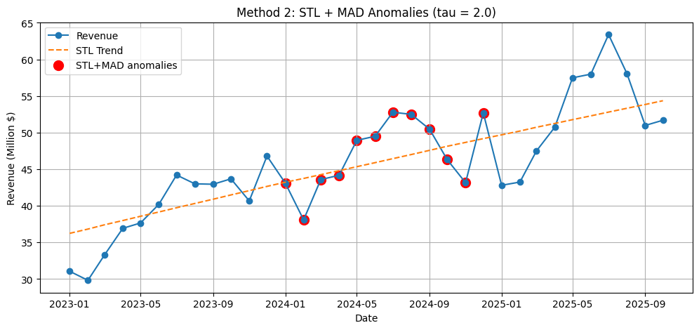

```python
plt.figure(figsize=(12, 5))
plt.plot(ts_stl.index, ts_stl["REVENUE_M"], marker="o", label="Revenue")
plt.plot(ts_stl.index, ts_stl["TREND"], linestyle="--", label="STL Trend")

# Overlay STL anomalies
anoms_stl = ts_stl[ts_stl["STL_anomaly"]]
plt.scatter(anoms_stl.index, anoms_stl["REVENUE_M"],
            color="red", s=100, label="STL+MAD anomalies")

plt.title(f"Method 2: STL + MAD Anomalies (tau = {tau})")
plt.xlabel("Date")
plt.ylabel("Revenue (Million $)")
plt.legend()
plt.grid(True)
plt.show()
```

## 6.1 Method 2 results (take one, not satisfactory)

The STL decomposition flags many observations in 2024 as anomalies, even though visually these points track the revenue pattern reasonably well. This happens because STL assumes a stable, repeating seasonal structure, but my dataset contains fewer than three full annual cycles and exhibits evolving seasonal behavior.

Since the STL decomposition imposed a seasonal structure that the dataset does not support (due to fewer than three annual cycles), I use a trend-only decomposition using LOESS smoothing. This gives a clean remainder series (R_t) that captures short-run deviations around a smooth trend. To detect anomalies, I apply the robust MAD rule:

$$ \text{Anomaly if } \lvert R_t \rvert > \tau \cdot \text{MAD}(R), $$

where MAD is the median absolute deviation and (\tau) controls the detection sensitivity.

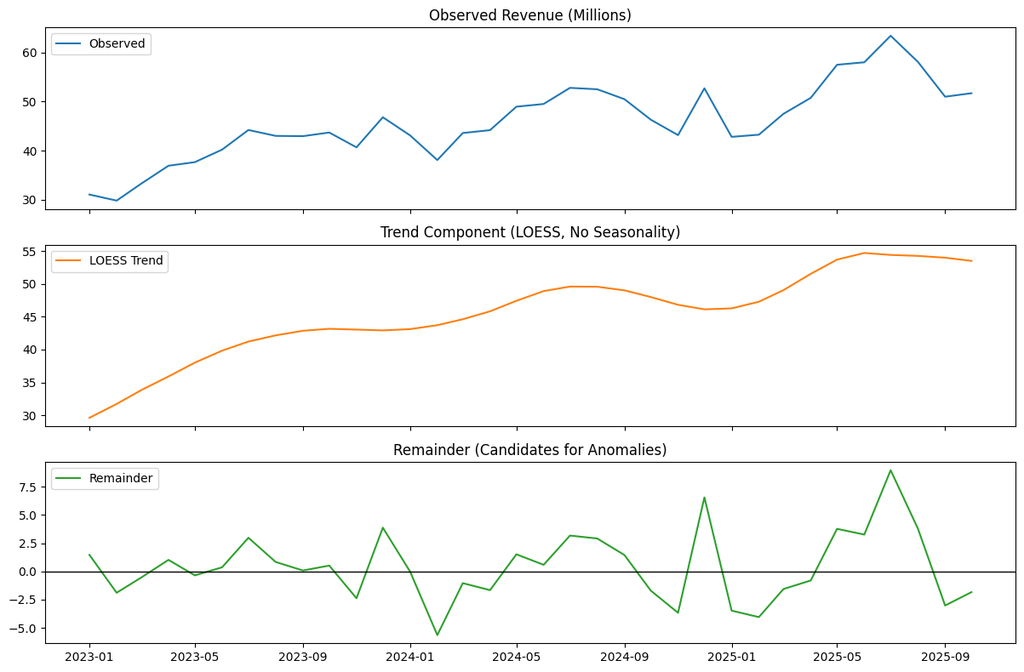

```python
# Method 2, take 2, turning off seasonality to prevent overfitting seasonality and artificially inflating noise components


# Ensure sorted and indexed by DATE
ts_trend = ts.sort_values("DATE").set_index("DATE").copy()
y = ts_trend["REVENUE_M"].values
t = np.arange(len(y))  # numeric time index

# Fit LOESS (LOWESS in statsmodels terminology)
# frac controls the smoothness: larger = smoother trend
trend_loess = lowess(y, t, frac=0.3, return_sorted=False)

# Store in DataFrame
ts_trend["TREND_loess"] = trend_loess
ts_trend["REMAINDER_loess"] = ts_trend["REVENUE_M"] - ts_trend["TREND_loess"]

# Plot observed series, trend, and remainder (no seasonality)
fig, axes = plt.subplots(3, 1, figsize=(12, 8), sharex=True)

axes[0].plot(ts_trend.index, ts_trend["REVENUE_M"], label="Observed", color="C0")
axes[0].set_title("Observed Revenue (Millions)")
axes[0].legend(loc="upper left")

axes[1].plot(ts_trend.index, ts_trend["TREND_loess"], label="LOESS Trend", color="C1")
axes[1].set_title("Trend Component (LOESS, No Seasonality)")
axes[1].legend(loc="upper left")

axes[2].plot(ts_trend.index, ts_trend["REMAINDER_loess"], label="Remainder", color="C2")
axes[2].axhline(0, color="black", linewidth=1)
axes[2].set_title("Remainder (Candidates for Anomalies)")
axes[2].legend(loc="upper left")

plt.tight_layout()
plt.show()
```

```python
# Extract remainder
R = ts_trend["REMAINDER_loess"].values

# Compute median absolute deviation
median_R = np.median(R)
mad = np.median(np.abs(R - median_R))
mad_scaled = 1.4826 * mad  # consistent with earlier definition

print("MAD (raw):", mad)
print("MAD (scaled):", mad_scaled)

# Choose tau
tau = 2.5  # you can try 2.0, 2.5, 3.0

threshold = tau * mad_scaled
print("Threshold:", threshold)

# Flag anomalies
ts_trend["LOESS_anomaly"] = np.abs(ts_trend["REMAINDER_loess"]) > threshold

# Show anomalies
anoms_loess = ts_trend[ts_trend["LOESS_anomaly"]]
anoms_loess
```

```
MAD (raw): 1.991506453840202
MAD (scaled): 2.9526074684634835
Threshold: 7.381518671158709
```

| DATE | REVENUE_M | TREND_loess | REMAINDER_loess | LOESS_anomaly |
| --- | --- | --- | --- | --- |
| 2025-07-01 | 63.390907 | 54.425431 | 8.965476 | True |

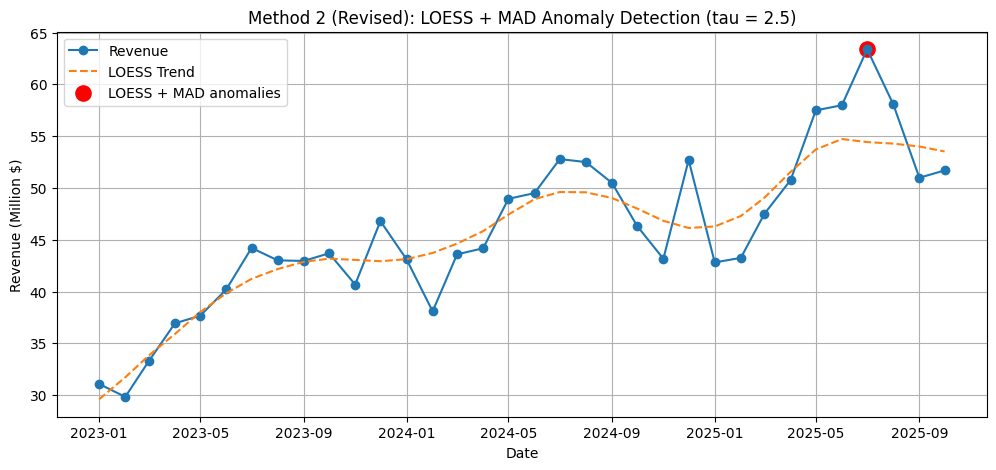

```python
plt.figure(figsize=(12,5))

plt.plot(ts_trend.index, ts_trend["REVENUE_M"], marker='o', label="Revenue")
plt.plot(ts_trend.index, ts_trend["TREND_loess"], linestyle='--', label="LOESS Trend")

# Overlay anomalies
plt.scatter(
    anoms_loess.index,
    anoms_loess["REVENUE_M"],
    color="red",
    s=120,
    label="LOESS + MAD anomalies"
)

plt.title(f"Method 2 (Revised): LOESS + MAD Anomaly Detection (tau = {tau})")
plt.xlabel("Date")
plt.ylabel("Revenue (Million $)")
plt.legend()
plt.grid(True)
plt.show()
```

## 6.2 Method 2 results again (take two, without seasonal components)

The revised Method 2, based on a LOESS trend decomposition without seasonality, produces a far more interpretable remainder series than the original STL approach. After removing only the smooth long-run trend, the residuals $R_t$ reflect short-run deviations that are not driven by mis-specified seasonal structure.

# 7. Case Study: Why Algorithmic Methods Are Not Applied

I do not apply algorithmic anomaly-detection methods (e.g., Isolation Forest, One-Class SVM, LOF) to this dataset for two reasons. First, the series is short—fewer than 36 monthly observations—and algorithmic methods rely on learning a meaningful boundary or density structure from the data. With such a limited sample, these models cannot form stable partitions or isolation paths, often resulting in unreliable or unstable anomaly scores. Second, the dataset is univariate, containing only a single revenue metric. Algorithmic methods are most useful in higher-dimensional settings where anomalies manifest as unusual combinations of features. In this case, simpler model-based and decomposition-based methods are not only more interpretable but also more statistically appropriate.

Given these considerations, the Z-score residual method and the LOESS–MAD method provide sufficient and robust anomaly detection for the analysis.

# 8. Conclusion

Across the two methods applied in this notebook, both anomaly-detection procedures independently identify the same revenue spike, in July 2025, as the only statistically unusual observation. Method 1 flags this point whenever the Z-score threshold

$$ |e_t| > k \cdot \sigma_e $$

is set to a moderately sensitive value ((k = 2)), and Method 2 confirms this result through the robust LOESS–MAD rule:

$$ |R_t| > \tau \cdot \text{MAD}(R). $$

The convergence of these two conceptually distinct approaches strengthens the conclusion that July 2025 represents a genuine outlier rather than model noise or an artifact of seasonal mis-specification. More broadly, this example illustrates the importance of matching methods to data characteristics: Z-scores provide a simple benchmark, STL requires stable seasonal structure, and LOESS–MAD offers a flexible alternative when seasonality is weak or the sample is short. In this dataset, a trend-only decomposition proves sufficient and yields a clear, interpretable anomaly profile. Together, these methods demonstrate a coherent and defensible strategy for anomaly detection in short monthly operational time series.